# SET UP

```python
import numpy as np
import pandas as pd
import matplotlib.pyplot as plt
import os
import tensorflow as tf
from os import listdir
from os.path import isfile, join
import random
import shutil
from matplotlib.image import imread
from keras.callbacks import ModelCheckpoint, EarlyStopping, CSVLogger

from tensorflow.keras.utils import Sequence
import time
import seaborn as sns
import DCGAN as gan
import json
```

```python
IMG_DIR = './PokemonData'
dirs = os.listdir(IMG_DIR)
print(dirs[:5])
```

```
['Abra', 'Aerodactyl', 'Alakazam', 'Alolan Sandslash', 'Arbok']
```

# DATA EXTRACTOR

```python
def files_info_extractor(path):
    dir_list = os.listdir(path)
    y = []
    X = []
    for i in range(len(dir_list)):
        files = os.listdir(os.path.join(path,dir_list[i]))
        for j in range(len(files)):
            X.append([files[j],dir_list[i]])
    return X
```

```python
x = files_info_extractor(IMG_DIR)
X = pd.DataFrame(x,columns=["file","label"])
X
```

|  | file | label |
| --- | --- | --- |
| 0 | 0282b2f3a22745f1a436054ea15a0ae5.jpg | Abra |
| 1 | 06b9eec4827d4d49b1b4c284308708df.jpg | Abra |
| 2 | 10a9f06ec6524c66b779ea80354f8519.jpg | Abra |
| 3 | 1788abb8b51f48509cfac8067bd99e14.jpg | Abra |
| 4 | 28cfad92ad934d1f9b579cbff4b5d012.jpg | Abra |
| ... | ... | ... |
| 6820 | dd387067380e4d1f8672c30d4b567fac.jpg | Zubat |
| 6821 | e1997a18e61641a4b0e701f6bc4c70f4.jpg | Zubat |
| 6822 | e6cba9a117d64d849fcc389e04e92e11.jpg | Zubat |
| 6823 | f8788465c10a4ab8bb0aeb992ec060ce.jpg | Zubat |
| 6824 | fccfe4de71a543349378b09d91d3f745.jpg | Zubat |

6825 rows × 2 columns

```python
def create_train_val_test_folder():
    os.system("mkdir train")
    os.system("mkdir test")
    os.system("mkdir val")
def clean_images():
    os.system("rm -r train/* test/* val/*")
    os.system("find train/ -name '*.*' -type f -delete")
    os.system("find val/ -name '*.*' -type f -delete")
    os.system("find test/ -name '*.*' -type f -delete")
def data_extractor(class_pct,train_pct,val_pct,test_pct):

    sub_classes = random.sample(dirs,int(len(dirs)*class_pct))
    for cla in sub_classes:
        os.system('mkdir "train/'+cla+'"')
        os.system('mkdir "test/'+cla+'"')
        os.system('mkdir "val/'+cla+'"')
        os.system("find train/"+cla+" -name '*.*' -type f -delete")
        os.system("find val/"+cla+" -name '*.*' -type f -delete")
        os.system("find test/"+cla+" -name '*.*' -type f -delete")
        temp_files = os.listdir(os.path.join(IMG_DIR,cla))
        files = [f for f in temp_files if isfile(os.path.join(IMG_DIR, cla,f))]
        train_files = random.sample(files,int(len(files)*(train_pct+val_pct+test_pct)))
        val_files = random.sample(train_files,int(len(files)*(val_pct+test_pct)))
        test_files = random.sample(val_files,int(len(files)*test_pct))
        train_files = [x for x in train_files if x not in val_files]
        val_files = [x for x in val_files if x not in test_files]
        for file in train_files:
            shutil.copy(os.path.join(IMG_DIR,cla,file), os.path.join('train',cla,file))
        for file in val_files:
            shutil.copy(os.path.join(IMG_DIR,cla,file), os.path.join('val',cla,file))
        for file in test_files:
            shutil.copy(os.path.join(IMG_DIR,cla,file), os.path.join('test',cla,file))

def data_extractor_gan(classes,train_pct, val_pct, test_pct):
    for cla in classes:
        os.system('mkdir "train/'+cla+'"')
        os.system('mkdir "test/'+cla+'"')
        os.system('mkdir "val/'+cla+'"')
        os.system("find train/"+cla+" -name '*.*' -type f -delete")
        os.system("find val/"+cla+" -name '*.*' -type f -delete")
        os.system("find test/"+cla+" -name '*.*' -type f -delete")
        os.system('mkdir "include_gan"')
        os.system('mkdir "include_gan/train/'+cla+'"')
        os.system('mkdir "include_gan/test/'+cla+'"')
        os.system('mkdir "include_gan/val/'+cla+'"')
        os.system("find include_gan/train/"+cla+" -name '*.*' -type f -delete")
        os.system("find include_gan/val/"+cla+" -name '*.*' -type f -delete")
        os.system("find include_gan/test/"+cla+" -name '*.*' -type f -delete")
        temp_files = os.listdir(os.path.join(IMG_DIR,cla))
        files = [f for f in temp_files if isfile(os.path.join(IMG_DIR, cla,f))]
        train_files = random.sample(files,int(len(files)*(train_pct+val_pct+test_pct)))
        val_files = random.sample(train_files,int(len(files)*(val_pct+test_pct)))
        test_files = random.sample(val_files,int(len(files)*test_pct))
        train_files = [x for x in train_files if x not in val_files]
        val_files = [x for x in val_files if x not in test_files]
        for file in train_files:
            shutil.copy(os.path.join(IMG_DIR,cla,file), os.path.join('include_gan','train',cla,file))
            shutil.copy(os.path.join(IMG_DIR,cla,file), os.path.join('train',cla,file))
        for file in val_files:
            shutil.copy(os.path.join(IMG_DIR,cla,file), os.path.join('include_gan','val',cla,file))
            shutil.copy(os.path.join(IMG_DIR,cla,file), os.path.join('val',cla,file))
        for file in test_files:
            shutil.copy(os.path.join(IMG_DIR,cla,file), os.path.join('include_gan','test',cla,file))
            shutil.copy(os.path.join(IMG_DIR,cla,file), os.path.join('test',cla,file))
        temp_files = os.listdir(os.path.join("savedData",cla))
        files = [f for f in temp_files if isfile(os.path.join("savedData", cla,f))]
        for file in files:
            shutil.copy(os.path.join("savedData",cla,file), os.path.join("include_gan",'train',cla,file))
```

```python
gan_test_class = ["Arbok","Bulbasaur","Caterpie","Charizard","Cloyster","Cubone","Dewgong","Ditto","Dodrio","Dragonite","Dratini","Ekans"]
```

```python
data_extractor_gan(class_names[:30],0.7,0.2,0.1)
```

```python
create_train_val_test_folder()
#clean_images()
data_extractor(1,0.7,0.2,0.1)
```

# USE GAN MODEL TO GENERATE MORE IMAGES

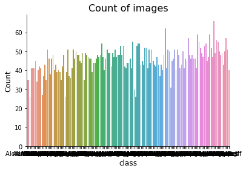

```python
plt.title('Count of images', size=16)
sns.countplot(X["label"])
plt.ylabel('Count', size=12)
plt.xlabel('class', size=12)
sns.despine(top=True, right=True, left=False, bottom=False)
#plt.savefig("./plots/count_of_images_without_gan.png")
plt.show()
```

```python
class_names = X["label"].unique()
max_num = X["label"].value_counts()
```

```python
os.system("mkdir savedData")
for cla in class_names:
    os.system("mkdir savedData/"+cla)
```

```python
class_names
```

```
array(['Abra', 'Aerodactyl', 'Alakazam', 'Alolan Sandslash', 'Arbok',
       'Arcanine', 'Articuno', 'Beedrill', 'Bellsprout', 'Blastoise',
       'Bulbasaur', 'Butterfree', 'Caterpie', 'Chansey', 'Charizard',
       'Charmander', 'Charmeleon', 'Clefable', 'Clefairy', 'Cloyster',
       'Cubone', 'Dewgong', 'Diglett', 'Ditto', 'Dodrio', 'Doduo',
       'Dragonair', 'Dragonite', 'Dratini', 'Drowzee', 'Dugtrio', 'Eevee',
       'Ekans', 'Electabuzz', 'Electrode', 'Exeggcute', 'Exeggutor',
       'Farfetchd', 'Fearow', 'Flareon', 'Gastly', 'Gengar', 'Geodude',
       'Gloom', 'Golbat', 'Goldeen', 'Golduck', 'Golem', 'Graveler',
       'Grimer', 'Growlithe', 'Gyarados', 'Haunter', 'Hitmonchan',
       'Hitmonlee', 'Horsea', 'Hypno', 'Ivysaur', 'Jigglypuff', 'Jolteon',
       'Jynx', 'Kabuto', 'Kabutops', 'Kadabra', 'Kakuna', 'Kangaskhan',
       'Kingler', 'Koffing', 'Krabby', 'Lapras', 'Lickitung', 'Machamp',
       'Machoke', 'Machop', 'Magikarp', 'Magmar', 'Magnemite', 'Magneton',
       'Mankey', 'Marowak', 'Meowth', 'Metapod', 'Mew', 'Mewtwo',
       'Moltres', 'MrMime', 'Muk', 'Nidoking', 'Nidoqueen', 'Nidorina',
       'Nidorino', 'Ninetales', 'Oddish', 'Omanyte', 'Omastar', 'Onix',
       'Paras', 'Parasect', 'Persian', 'Pidgeot', 'Pidgeotto', 'Pidgey',
       'Pikachu', 'Pinsir', 'Poliwag', 'Poliwhirl', 'Poliwrath', 'Ponyta',
       'Porygon', 'Primeape', 'Psyduck', 'Raichu', 'Rapidash', 'Raticate',
       'Rattata', 'Rhydon', 'Rhyhorn', 'Sandshrew', 'Sandslash',
       'Scyther', 'Seadra', 'Seaking', 'Seel', 'Shellder', 'Slowbro',
       'Slowpoke', 'Snorlax', 'Spearow', 'Squirtle', 'Starmie', 'Staryu',
       'Tangela', 'Tauros', 'Tentacool', 'Tentacruel', 'Vaporeon',
       'Venomoth', 'Venonat', 'Venusaur', 'Victreebel', 'Vileplume',
       'Voltorb', 'Vulpix', 'Wartortle', 'Weedle', 'Weepinbell',
       'Weezing', 'Wigglytuff', 'Zapdos', 'Zubat'], dtype=object)
```

```python
pokemon_class = ["Zapdos"]
```

[figure not shown]

[output not shown]

```python
import DCGAN as gan

for pokemon in pokemon_class:
    train_dataset = gan.create_dataset(os.path.join(IMG_DIR, pokemon) + "/*")
    save = str("./" + pokemon + "/")

    gan.train(train_dataset, epochs=4000, save_after=100, save_URL = save,num=36)
```

# TAKE A LOOK AT THE DATASET

[figure not shown]

```python
test_path = 'PokemonData/Abra/4e554e4a0f624656a7b1542b679b6157.jpg'
plt.imshow(imread(test_path))
```

# DATA AUGMATION USING ImageDataGenerator

[figure not shown]

```python
from keras.preprocessing.image import ImageDataGenerator

baselineDataGen = ImageDataGenerator()
rotateDataGen = ImageDataGenerator(rotation_range=40)
rescaleDataGen = ImageDataGenerator(rescale = 1./255)
zcaDataGen = ImageDataGenerator(zca_whitening=True)
zoomDataGen = ImageDataGenerator(zoom_range=0.5)
allDataGen = ImageDataGenerator(rotation_range=20,
                               rescale = 1./255,
                               width_shift_range=0.1,
                               height_shift_range=0.1,
                               shear_range=0.1,
                               zoom_range=0.1,
                               horizontal_flip=True,
                               vertical_flip = True,
                               fill_mode='nearest')

plt.imshow(baselineDataGen.random_transform(imread(test_path)))
plt.imshow(rotateDataGen.random_transform(imread(test_path)))
plt.imshow(rescaleDataGen.random_transform(imread(test_path)))
plt.imshow(zcaDataGen.random_transform(imread(test_path)))
plt.imshow(zoomDataGen.random_transform(imread(test_path)))
plt.imshow(allDataGen.random_transform(imread(test_path)))
```

```python
image_shape = (256,256,3)


def generateDataFromDirectory(dg):
    train = dg.flow_from_directory('train/',target_size=image_shape[:2],
                                                color_mode='rgb',
                                                batch_size=100,
                                                class_mode='categorical')
    test = dg.flow_from_directory('test/',target_size=image_shape[:2],
                                                color_mode='rgb',
                                                batch_size=100,
                                                class_mode='categorical')
    val = dg.flow_from_directory('val/',target_size=image_shape[:2],
                                                color_mode='rgb',
                                                batch_size=15,
                                                class_mode='categorical')
    return train, test, val

def generateDataFromDirectory_gan(dg):
    train = dg.flow_from_directory('include_gan/train/',target_size=image_shape[:2],
                                                color_mode='rgb',
                                                batch_size=100,
                                                class_mode='categorical')
    test = dg.flow_from_directory('include_gan/test/',target_size=image_shape[:2],
                                                color_mode='rgb',
                                                batch_size=100,
                                                class_mode='categorical')
    val = dg.flow_from_directory('include_gan/val/',target_size=image_shape[:2],
                                                color_mode='rgb',
                                                batch_size=100,
                                                class_mode='categorical')
    return train, test, val
```

## create callback_list for building model

```python
os.system("mkdir saved_models")
filepath = "saved_models/weight-model-improvement-{epoch:02d}-{val_accuracy:.2f}-"+time.strftime("%Y%m%d-%H%M%S")+".h5"
#checkpoint = ModelCheckpoint(filepath, monitor="val_accuracy",verbose=1,save_best_only=True, model="max", save_weights_only=False)
#earlystopping = EarlyStopping(monitor="val_loss",patience=15,verbose=1,restore_best_weights=True)
reduce_lr = tf.keras.callbacks.ReduceLROnPlateau(
    monitor='val_loss', factor=0.1, patience=10, verbose=0,
    mode='auto', min_delta=0.0001, cooldown=0, min_lr=0,
)
log_csv = CSVLogger("my_logs.csv",separator=',', append=False)
callback_list = [earlystopping,log_csv]
callback_list_with_reduction = [earlystopping,log_csv,reduce_lr]
```

[output not shown]

## define function to create baseline model which we use as a baseline to compare with other models

```python
from keras.models import Sequential
from keras.layers import Conv2D, MaxPool2D, Dropout, Flatten, Dense, Activation, BatchNormalization, Lambda
from keras.preprocessing.image import ImageDataGenerator
from tensorflow.keras.optimizers import Adam

ClassNum = 20
def build_baseline():
    model = Sequential()

    model.add(Conv2D(filters=64,kernel_size=(3,3),padding='same',input_shape=image_shape,activation='relu'))
    model.add(MaxPool2D(pool_size=(2,2)))

    model.add(Conv2D(filters=128,kernel_size=(3,3),padding='same',input_shape=image_shape,activation='relu'))
    model.add(MaxPool2D(pool_size=(2,2)))

    model.add(Conv2D(filters=256,kernel_size=(3,3),padding='same',input_shape=image_shape,activation='relu'))
    model.add(MaxPool2D(pool_size=(2,2)))

    model.add(Flatten())

    model.add(Dense(256,activation='relu'))

    model.add(Dense(128,activation='relu'))

    model.add(Dense(ClassNum,activation='softmax'))

    model.compile(loss='categorical_crossentropy', optimizer=Adam(learning_rate=0.0001), metrics=['accuracy'])

    return model
```

## define function to compare the original dataset and dataset with gan included

```python
def compared_with_without_gan():
    historys = []
    train, test, val = generateDataFromDirectory(allDataGen)
    gan_train, gan_test, gan_val = generateDataFromDirectory_gan(allDataGen)
    model = build_baseline()
    gan_model = build_baseline()
    history = model.fit(train, epochs=100, validation_data=val)
    gan_history = gan_model.fit(gan_train, epochs=100,validation_data=gan_val)
    historys.append(history)
    historys.append(gan_history)
    loss_history = pd.DataFrame(history.history)
    gan_loss_history = pd.DataFrame(gan_history.history)
    plt.plot(loss_history['val_accuracy'],label="original")
    plt.plot(gan_loss_history['val_accuracy'],label="gan")
    plt.legend()
    plt.savefig("./plots/compared_with_without_gan.png")
    plt.show()
    return historys
```

```python
gan_historys = compared_with_without_gan()
```

```
Found 543 images belonging to 20 classes.
Found 71 images belonging to 20 classes.
Found 158 images belonging to 20 classes.
Found 1263 images belonging to 20 classes.
Found 71 images belonging to 20 classes.
Found 158 images belonging to 20 classes.
```

[output not shown]

[output cut: 35 more lines]

[output not shown]

```python
#json.dump(gan_historys[0].history,open("./historys/compared_generators_original",'w'))
#json.dump(gan_historys[1].history,open("./historys/compared_generators_gan",'w'))
```

## define function to compare the accuracy of different generators

```python
def compared_generators(gens,labels):
    historys = []
    for i in range(len(gens)):
        gen = gens[i]
        label = labels[i]
        train, test, val = generateDataFromDirectory(gen)
        model = build_baseline()
        history = model.fit(train, epochs=100, validation_data=val)
        historys.append(history)
        loss_history = pd.DataFrame(history.history)
        plt.plot(loss_history['val_accuracy'],label=label)
    plt.legend()
    #plt.savefig("./plots/compared_generators_"+time.strftime("%Y%m%d-%H%M%S")+".png")
    plt.savefig("./plots/compared_generators.png")
    plt.show()
    return historys
```

```
Found 543 images belonging to 20 classes.
Found 71 images belonging to 20 classes.
Found 158 images belonging to 20 classes.
Found 543 images belonging to 20 classes.
Found 71 images belonging to 20 classes.
Found 158 images belonging to 20 classes.
Found 543 images belonging to 20 classes.
Found 71 images belonging to 20 classes.
Found 158 images belonging to 20 classes.
Found 543 images belonging to 20 classes.
Found 71 images belonging to 20 classes.
Found 158 images belonging to 20 classes.
```

```
Found 543 images belonging to 20 classes.
Found 71 images belonging to 20 classes.
Found 158 images belonging to 20 classes.
```

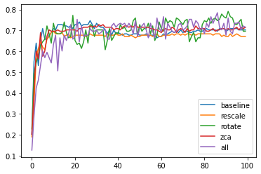

```python
gens = [baselineDataGen, rescaleDataGen, rotateDataGen, zcaDataGen, allDataGen]
labels = ["baseline","rescale","rotate","zca","all"]
generators_historys = compared_generators(gens,labels)
json.dump(generators_historys[0].history,open("./historys/compared_generators_default",'w'))
json.dump(generators_historys[1].history,open("./historys/compared_generators_rescale",'w'))
json.dump(generators_historys[2].history,open("./historys/compared_generators_rotate",'w'))
json.dump(generators_historys[3].history,open("./historys/compared_generators_zca",'w'))
json.dump(generators_historys[4].history,open("./historys/compared_generators_all",'w'))
```

```python
#all_loss_history = pd.DataFrame(all_history.history)
#all_loss_history[['accuracy','val_accuracy']].plot()
#all_loss_history[['loss','val_loss']].plot()
```

https://stackoverflow.com/questions/51748514/does-imagedatagenerator-add-more-images-to-my-dataset  
Further, I think it's worth clarifying the meaning of "augmentation" in this context: basically we are augmenting the images when we use ImageDataGenerator and enabling its augmentation capabilities. But the word "augmentation" here does not mean, say, if we have 100 original training images we end up having 1000 images per epoch after augmentation (i.e. the number of training images does not increase per epoch). Instead, it means we use a different transformation of each image in each epoch; hence, if we train our model for, say, 5 epochs, we have used 5 different versions of each original image in training (or 100 * 5 = 500 different images in the whole training, instead of using just the 100 original images in the whole training). To put it differently, the total number of unique images increases in the whole training from start to finish, and not per epoch.

## define function to create model and compare the accuracy of different combination of decay_rate, decay_step,and initial rate

```python
def build_model_with_decay(initial_rate,decay_step, decay_rate):
    model = Sequential()

    model.add(Conv2D(filters=64,kernel_size=(3,3),padding='same',input_shape=image_shape,activation='relu'))
    model.add(MaxPool2D(pool_size=(2,2)))

    model.add(Conv2D(filters=128,kernel_size=(3,3),padding='same',input_shape=image_shape,activation='relu'))
    model.add(MaxPool2D(pool_size=(2,2)))

    model.add(Conv2D(filters=256,kernel_size=(3,3),padding='same',input_shape=image_shape,activation='relu'))
    model.add(MaxPool2D(pool_size=(2,2)))

    model.add(Flatten())

    model.add(Dense(256,activation='relu'))

    model.add(Dense(128,activation='relu'))

    model.add(Dense(ClassNum,activation='softmax'))
    lr_schedule = tf.keras.optimizers.schedules.ExponentialDecay(
    initial_rate,
    decay_steps=decay_step,
    decay_rate=decay_rate,
    staircase=True)


    model.compile(loss='categorical_crossentropy', optimizer=Adam(learning_rate=lr_schedule), metrics=['accuracy'])

    return model
```

```python
def compared_decay_rate():
    initials = [0.001,0.0001]
    steps = [10000,100000]
    rates = [0.96]
    historys =[]
    for initial in initials:
        for step in steps:
            for rate in rates:
                train, test, val = generateDataFromDirectory(allDataGen)
                model = build_model_with_decay(initial, step, rate)
                history = model.fit(train, epochs=100, validation_data=val)
                historys.append(history)
                loss_history = pd.DataFrame(history.history)
                plt.plot(loss_history['val_accuracy'],label="initial: "+str(initial)+ " steps: "+str(step)+ " rate: "+str(rate))
    plt.legend()
    plt.show()
    plt.savefig("compared_decay_rate_"+time.strftime("%Y%m%d-%H%M%S")+".png")
    return historys
```

```
Found 543 images belonging to 20 classes.
Found 71 images belonging to 20 classes.
Found 158 images belonging to 20 classes.
Found 543 images belonging to 20 classes.
Found 71 images belonging to 20 classes.
Found 158 images belonging to 20 classes.
Found 543 images belonging to 20 classes.
Found 71 images belonging to 20 classes.
Found 158 images belonging to 20 classes.
Found 543 images belonging to 20 classes.
Found 71 images belonging to 20 classes.
Found 158 images belonging to 20 classes.
```

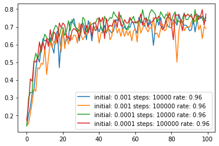

```python
decay_historys = compared_decay_rate()
```

```python
json.dump(decay_historys[0].history,open("./historys/compared_decay",'w'))
json.dump(generators_historys[1].history,open("./historys/compared_generators_rescale",'w'))
json.dump(generators_historys[2].history,open("./historys/compared_generators_rotate",'w'))
json.dump(generators_historys[3].history,open("./historys/compared_generators_zca",'w'))
json.dump(generators_historys[4].history,open("./historys/compared_generators_all",'w'))
```

## define function to compare accuracy between model using decay and reduction

```python
def compared_reduction_decay():
    train, test, val = generateDataFromDirectory(allDataGen)
    reduction_model = build_baseline()
    decay_model = build_model_with_decay(0.0001,10000,0.96)
    #combined_model = build_model_with_decay(0.001,10000,0.96)
    reduction_history = reduction_model.fit(train, epochs=20,validation_data=val,callbacks=callback_list_with_reduction)
    decay_history = decay_model.fit(train, epochs=10,validation_data=val,callbacks=callback_list)
    #combined_history = combined_model.fit(train, epochs=10,validation_data=val,callbacks=callback_list_with_reduction)

    historys = [reduction_history, decay_history]
    reduction_loss_history = pd.DataFrame(reduction_history.history)
    decay_loss_history = pd.DataFrame(decay_history.history)
    #combined_loss_history = pd.DataFrame(combined_history.history)
    plt.plot(reduction_loss_history['val_accuracy'],label="reduction")
    plt.plot(decay_loss_history['val_accuracy'],label="decay")
    #plt.plot(combined_loss_history['val_accuracy'],label="combined")
    plt.legend()
    plt.savefig("compared_reduction_rate_"+time.strftime("%Y%m%d-%H%M%S")+".png")
    plt.show()
    return historys
```

[output not shown]

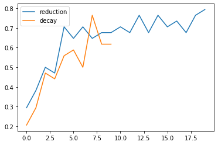

```
[<keras.callbacks.History at 0x7f3cf068f580>,
 <keras.callbacks.History at 0x7f3d10052d60>]
```

```python
compared_reduction_decay()
```

# building the final model and evaluate it

```python
os.system("mkdir saved_models")
filepath = "saved_models/weight-model-improvement-{epoch:02d}-{val_accuracy:.2f}-"+time.strftime("%Y%m%d-%H%M%S")+".h5"
checkpoint = ModelCheckpoint(filepath, monitor="val_accuracy",verbose=1,save_best_only=True, model="max", save_weights_only=False)
earlystopping = EarlyStopping(monitor="val_loss",patience=15,verbose=1,restore_best_weights=True)
reduce_lr = tf.keras.callbacks.ReduceLROnPlateau(
    monitor='val_loss', factor=0.1, patience=10, verbose=0,
    mode='auto', min_delta=0.0001, cooldown=0, min_lr=0,
)
log_csv = CSVLogger("my_logs.csv",separator=',', append=False)
callback_list = [checkpoint,earlystopping,log_csv]
callback_list_with_reduction = [checkpoint,earlystopping,log_csv,reduce_lr]
```

```python
from keras.models import Sequential
from keras.layers import Conv2D, MaxPool2D, Dropout, Flatten, Dense, Activation, BatchNormalization, Lambda
from keras.preprocessing.image import ImageDataGenerator
from tensorflow.keras.optimizers import Adam


def build_final_model():
    model = Sequential()

    model.add(Conv2D(filters=64,kernel_size=(3,3),padding='same',input_shape=image_shape,activation='relu'))
    model.add(MaxPool2D(pool_size=(2,2)))
    model.add(Conv2D(filters=128,kernel_size=(3,3),padding='same',input_shape=image_shape,activation='relu'))
    model.add(MaxPool2D(pool_size=(2,2)))
    model.add(Dropout(rate=0.25))
    model.add(BatchNormalization())
    model.add(Conv2D(filters=128,kernel_size=(3,3),padding='same',input_shape=image_shape,activation='relu'))
    model.add(MaxPool2D(pool_size=(2,2)))
    model.add(Conv2D(filters=128,kernel_size=(3,3),padding='same',input_shape=image_shape,activation='relu'))
    model.add(MaxPool2D(pool_size=(2,2)))
    model.add(Dropout(rate=0.25))
    model.add(BatchNormalization())


    model.add(Flatten())

    model.add(Dense(1024,activation='relu'))

    model.add(Dropout(rate=0.25))

    model.add(Dense(512,activation='relu'))

    model.add(Dense(30,activation='softmax'))

    model.compile(loss='categorical_crossentropy', optimizer=Adam(learning_rate=0.001), metrics=['accuracy'])

    return model
```

```python
train, test, val = generateDataFromDirectory(allDataGen)
reduction_model = build_final_model()
reduction_history = reduction_model.fit(train, epochs=100,validation_data=val,callbacks=callback_list_with_reduction)
reduction_loss_history = pd.DataFrame(reduction_history.history)

plt.legend()
plt.savefig("final_model"+time.strftime("%Y%m%d-%H%M%S")+".png")
plt.show()
```

```
Found 977 images belonging to 30 classes.
Found 172 images belonging to 30 classes.
Found 360 images belonging to 30 classes.
```

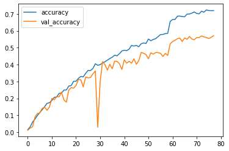

```python
reduction_loss_history[["accuracy","val_accuracy"]].plot()
```